# Análise Ambiental

Indicadores de Qualidade do Solo e  
Diagnóstico de Áreas Degradadas

Luiz Diego Vidal Santos

## Visão Geral da Aula

### Tópicos

- 1 Matéria orgânica e carbono orgânico
- 2 Densidade e porosidade
- 3 Infiltração
- 4 Agregação
- 5 Resistência à penetração
- 6 Cobertura vegetal
- 7 Erosão
- 8 Funcionalidade edáfica

**Objetivo da Aula**

Operacionalizar indicadores físicos, químicos e biológicos de qualidade do solo para o diagnóstico de áreas degradadas e a avaliação da funcionalidade edáfica.

# 1 - ATRIBUTOS FÍSICOS E QUÍMICOS

## Conceito de qualidade do solo

### Definição (Doran & Parkin, 1994)

> Capacidade contínua do solo de **funcionar como ecossistema vivo**, sustentando plantas, animais e seres humanos, mantendo ou melhorando a qualidade do ar e da água e promovendo a saúde humana, vegetal e animal.

### Funções edáficas

- Sustentação da produtividade biológica
- Filtragem e tamponamento
- Ciclagem de água e nutrientes
- Habitat para a biota
- Suporte físico para infraestrutura
- Estoque de carbono e regulação climática

**Atributos físicos**

| Atributo | Método | Interpretação |
| --- | --- | --- |
| Textura | Pipeta / Bouyoucos | Comportamento hidrico, susceptibilidade à erosão |
| Densidade do solo (Ds) | Anel volumétrico | > 1,4 g/cm³ indica compactação (textura média) |
| Porosidade total | Cálculo via Ds/Dp | Aeração e armazenamento |
| Macro/microporosidade | Mesa de tensão | Macro < 10% → problema de drenagem |
| Resistência à penetração | Penetrômetro | > 2 MPa restringe raiz |
| Estabilidade de agregados | DMP / DMG | Estruturação e resistência à erosão |
| Infiltração | Cilindros concêntricos | Capacidade de absorver água |

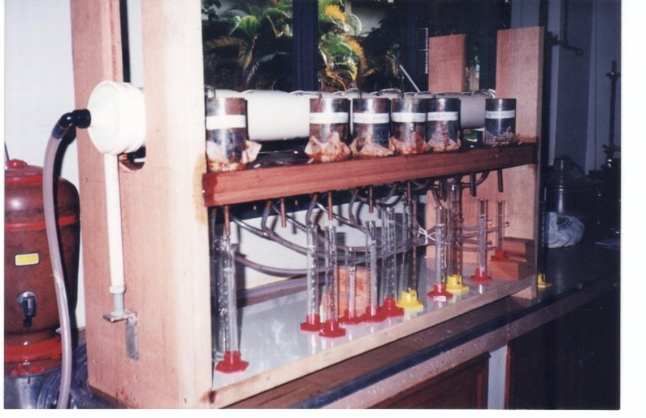

## Atributos químicos e biológicos

### Químicos

| Atributo | Faixa de referência |
| --- | --- |
| pH água | 5,5–6,5 (ideal cult.) |
| MO | > 25 g/kg (boa) |
| CTC efetiva | > 6 cmolᴄ/dm³ (média) |
| V% (sat. bases) | > 50% |
| P, K disponíveis | Variam por cultura |
| Al trocável | < 0,5 cmolᴄ/dm³ |

### Biológicos

- **Carbono microbiano (Cmic)** - biomassa ativa.
- **Respiração basal** - atividade metabólica.
- **qCO₂** - eficiência do uso de C.
- **Fauna do solo** (minhocas, colembolas).
- **Atividade enzimática** (fosfatase, urease).

**Matéria orgânica como integrador**

A MO funciona como **indicador-síntese** porque:

- Influencia agregação e estrutura.
- Regula retenção de água.
- Sustenta CTC e suprimento de N.
- Hospeda microbiota.
- É sensível ao manejo.

> A perda de **0,1% de C orgânico** pode ser detectada em monitoramentos de médio prazo (Vezzani & Mielniczuk, 2009).

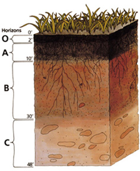

# 2 - AGREGAÇÃO, COBERTURA E DIAGNÓSTICO

## Funcionalidade edáfica

### Conceito-chave

Funcionalidade edáfica = capacidade do solo de **prover serviços ecossistêmicos** de forma sustentada:

| Serviço | Atributos-chave |
| --- | --- |
| Suporte à vegetação | Profundidade, fertilidade, retencao hírica |
| Regulação hídrica | Infiltração, condutividade, porosidade |
| Ciclagem de nutrientes | MO, CTC, microbiota |
| Estoque de C | C orgânico, estabilidade de agregados |
| Filtragem e tamponamento | Argila, MO, pH, CTC |

**Índices integrados (IQS)**

Abordagem do Conjunto Mínimo de Dados (CMD; Karlen *et al.*, 1997):

1. Selecionar atributos-chave (10–15 variáveis).
2. PCA para reduzir redundância.
3. Atribuir pesos por critério.
4. Normalizar para 0–1 (funções de pertinência).
5. Calcular **IQS = Σ (pesoᵢ × scoreᵢ)**.

IQS comparativo permite ranquear sistemas de manejo, tratamentos experimentais ou áreas de diagnóstico.

## Diagnóstico de áreas degradadas

### Sintomas de degradação

| Sintoma | Indicador |
| --- | --- |
| Solo exposto | Cobertura < 30% |
| Selamento | Crosta superficial, escorrimento rápido |
| Compactação | Ds > 1,4 g/cm³; RP > 2 MPa |
| Perda de estrutura | Agregados pequenos, baixa estabilidade |
| Perda de fertilidade | MO < 15 g/kg, V% < 30 |
| Erosão ativa | Sulcos, ravinas, pavimento desertico |
| Salinidade | Cond. elétrica > 4 dS/m |

**Roteiro de diagnóstico em campo**

1. Caminhamento orientado por declividade.
2. Pontos de amostragem em malha sistemática.
3. Tradagem para descrição morfológica.
4. Coleta para análises físico-químicas (lab.).
5. Penetrometria em malha (compactacao).
6. Registro fotográfico georreferenciado.
7. Síntese em **mapa de unidades funcionais** do solo.

# Referências

## Bibliografia da aula

- DORAN, J. W.; PARKIN, T. B. Defining and assessing soil quality. In: DORAN, J. W. *et al.* (ed.). **Defining soil quality for a sustainable environment**. Madison: SSSA, 1994. DOI: 10.2136/sssaspecpub35.c1.
- KARLEN, D. L. *et al.* Soil quality: a concept, definition, and framework for evaluation. **Soil Science Society of America Journal**, v. 61, n. 1, p. 4-10, 1997. DOI: 10.2136/sssaj1997.03615995006100010001x.
- VEZZANI, F. M.; MIELNICZUK, J. Uma visão sobre qualidade do solo. **Revista Brasileira de Ciência do Solo**, v. 33, n. 4, p. 743-755, 2009. DOI: 10.1590/S0100-06832009000400001.